# Hamlet_Kyle_Proj_2

```python
import pandas as pd
import matplotlib.pyplot as plt
```

```python
df = pd.read_csv("titanic.csv")
#reading the csv file

columns_to_remove = ["PassengerId", "Name", "Ticket", "Cabin", "SibSp", "Parch"]
df = df.drop(columns=columns_to_remove)
#removing irrelevant columns

df.isnull().sum()
#checking data set for null values

df.dropna(how='all',inplace=True)
#removing all rows that have null values

df.isnull().sum()
#checking to see that all nulls have been removed
```

```
Survived      0
Pclass        0
Sex           0
Age         177
Fare          0
Embarked      2
dtype: int64
```

1. Did passengers' class impact their survival rates during the Titanic disaster?

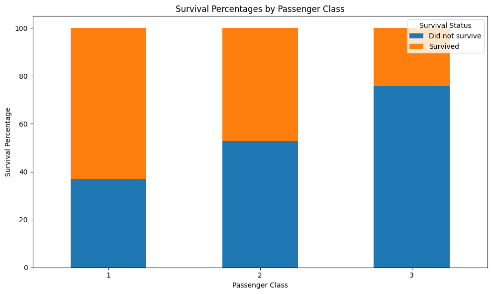

[output not shown]

```python
# Calculate survival percentages by Passenger Class
survival_percentages_class = df.groupby(['Pclass', 'Survived']).size().unstack().fillna(0)
survival_percentages_class = survival_percentages_class.div(survival_percentages_class.sum(axis=1), axis=0) * 100
survival_percentages_class = survival_percentages_class.rename({0: 'Did not survive', 1: 'Survived'}, axis=1)

survival_percentages_class.plot(kind='bar', stacked=True, figsize=(10, 6))
plt.xlabel('Passenger Class')
plt.ylabel('Survival Percentage')
plt.title('Survival Percentages by Passenger Class')
plt.legend(title='Survival Status', loc='upper right')
plt.xticks(rotation=0)
plt.tight_layout()
plt.show()
#plotting commands
```

As seen in the figure, there appears to be a correlation with passenger's class and their survival rate

2. Did the age of passengers play a crucial role in their ability to survive the Titanic's sinking?

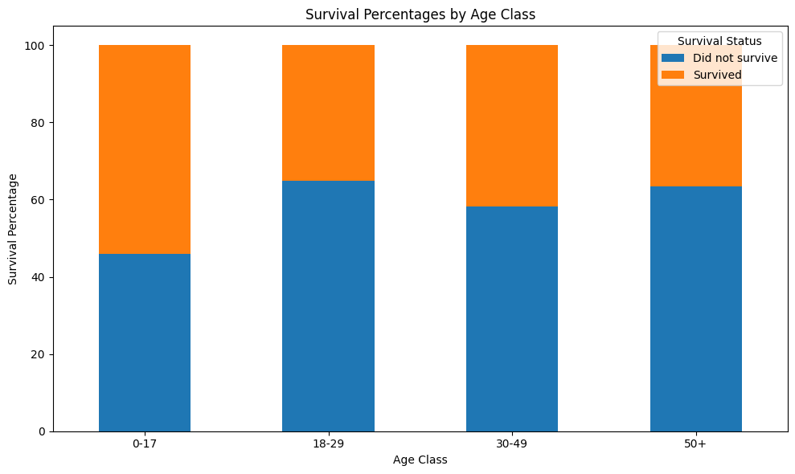

```python
df_age_not_null = df.dropna(subset=['Age']).copy()
#creates a new DataFrame excluding rows with no age values, also makes a copy of the data set to avoid the original data set

age_divisions = [0, 18, 30, 50, 100]
#defines age classes based on present day age grouping
age_ranges = ['0-17', '18-29', '30-49', '50+']
#defines the age range
df_age_not_null.loc[:, 'Age_class'] = pd.cut(df_age_not_null['Age'], bins=age_divisions, labels=age_ranges, right=False)

#calculates survival percentages by age class
survival_counts_age = df_age_not_null.groupby(['Age_class', 'Survived'], observed=True).size().unstack(fill_value=0)
survival_percentages_age = survival_counts_age.div(survival_counts_age.sum(axis=1), axis=0) * 100
survival_percentages_age = survival_percentages_age.rename({0: 'Did not survive', 1: 'Survived'}, axis=1)

survival_percentages_age.plot(kind='bar', stacked=True, figsize=(10, 6))
plt.xlabel('Age Class')
plt.ylabel('Survival Percentage')
plt.title('Survival Percentages by Age Class')
plt.legend(title='Survival Status', loc='upper right')
plt.xticks(rotation=0)
plt.tight_layout()
plt.show()
#plotting commands
```

As seen in the figure, the highest age class to survive where those within the 0-17 age class. This suggests that children were prioritized when evacuating the Titanic

3. Did the embarkation port from which passengers boarded the Titanic influence their likelihood of survival?

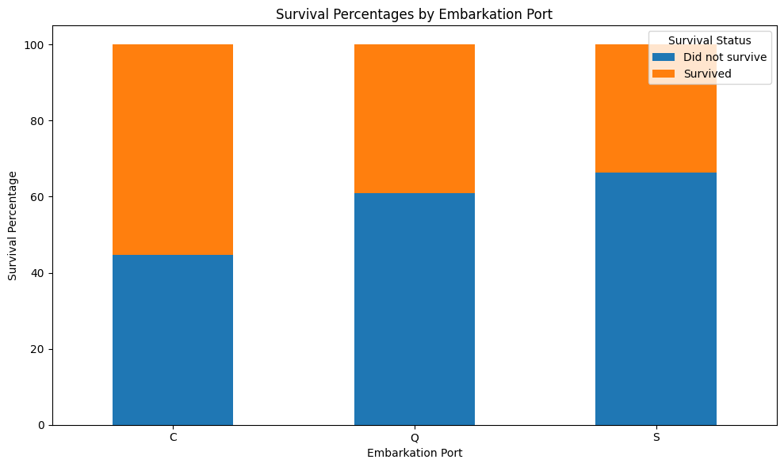

```python
df_embarked_not_null = df.dropna(subset=['Embarked']).copy()
#removes rows with no embarkation data, also creates a copy of the dataset

#calculate survival percentages by embarkation port
survival_percentages_embarked = df_embarked_not_null.groupby(['Embarked', 'Survived']).size().unstack(fill_value=0)
survival_percentages_embarked = survival_percentages_embarked.div(survival_percentages_embarked.sum(axis=1), axis=0) * 100
survival_percentages_embarked = survival_percentages_embarked.rename({0: 'Did not survive', 1: 'Survived'}, axis=1)

survival_percentages_embarked.plot(kind='bar', stacked=True, figsize=(10, 6))
plt.xlabel('Embarkation Port')
plt.ylabel('Survival Percentage')
plt.title('Survival Percentages by Embarkation Port')
plt.legend(title='Survival Status', loc='upper right')
plt.xticks(rotation=0)
plt.tight_layout()
plt.show()
#plotting commands
```

As seen in the figure, there is a 16 percent higher chance of survival if you embarked from the C Port. This could suggest those passengers were closer to lifevest/evacuation boats

4. Did the price of a passenger's ticket impact their chances of survival?

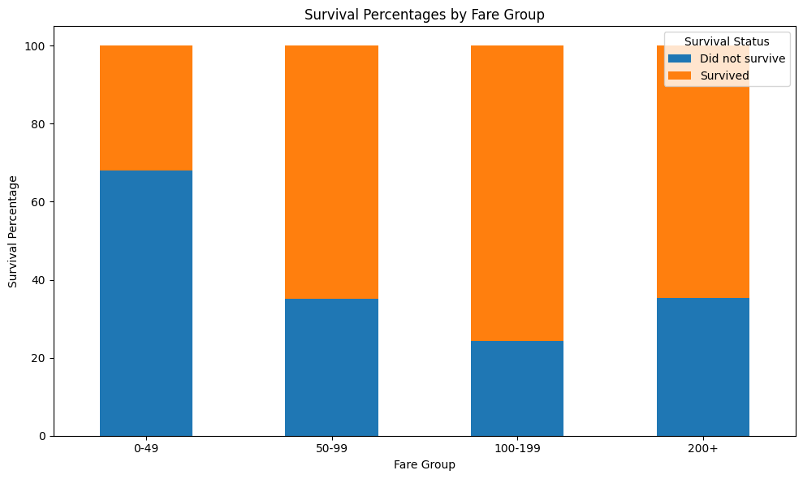

```python
df_fare_not_null = df.dropna(subset=['Fare']).copy()
#removes rows with no fare data, also makes a copy of the dataframe

fare_divisions = [0, 50, 100, 200, max(df_fare_not_null['Fare'])]
#defines fare groups. we chose to seperate fare groups by sets of 50.
fare_ranges = ['0-49', '50-99', '100-199', '200+']
#defines the ranges for the fare prices
df_fare_not_null.loc[:, 'Fare_Group'] = pd.cut(df_fare_not_null['Fare'], bins=fare_divisions, labels=fare_ranges, right=False)

#calculates survival percentages by fare group
survival_counts_fare = df_fare_not_null.groupby(['Fare_Group', 'Survived'], observed=True).size().unstack(fill_value=0)
survival_percentages_fare = survival_counts_fare.div(survival_counts_fare.sum(axis=1), axis=0) * 100
survival_percentages_fare = survival_percentages_fare.rename({0: 'Did not survive', 1: 'Survived'}, axis=1)

survival_percentages_fare.plot(kind='bar', stacked=True, figsize=(10, 6))
plt.xlabel('Fare Group')
plt.ylabel('Survival Percentage')
plt.title('Survival Percentages by Fare Group')
plt.legend(title='Survival Status', loc='upper right')
plt.xticks(rotation=0)
plt.tight_layout()
plt.show()
#plotting commands
```

As seen in the figure, those who paid 50 dollars or more had a significantly higher chance of surviving than those who paid less than 50 dollars. This could suggest that cheaper tickets were located on lower floors and therefore closest to the impact zones

5. How distributed were the fare prices between different age groups?

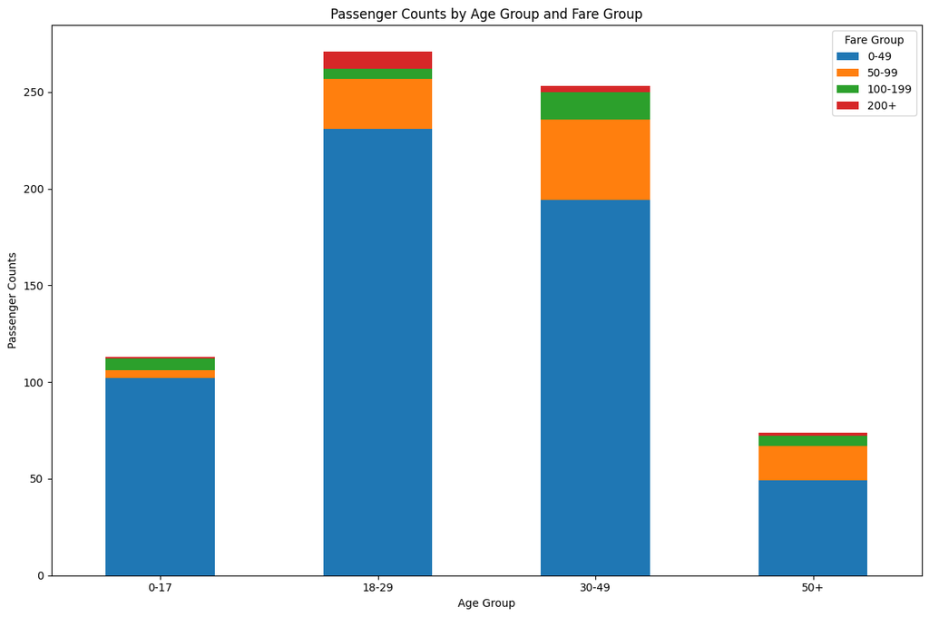

```python
df_age_fare_not_null = df.dropna(subset=['Age', 'Fare']).copy()
#remove rows with no age or fare data, also creates a copy of the original data set.

fare_divisions = [0, 50, 100, 200, max(df_age_fare_not_null['Fare'])]
#defines fare groups. we chose to seperate fare groups by sets of 50.
fare_ranges = ['0-49', '50-99', '100-199', '200+']
#defines the ranges for the fare prices
df_age_fare_not_null.loc[:, 'Fare_Group'] = pd.cut(df_age_fare_not_null['Fare'], bins=fare_divisions, labels=fare_ranges, right=False)

age_divisions = [0, 18, 30, 50, 100]
#defines age classes based on present day age grouping
age_ranges = ['0-17', '18-29', '30-49', '50+']
#defines the age range
df_age_fare_not_null.loc[:, 'Age_Group'] = pd.cut(df_age_fare_not_null['Age'], bins=age_divisions, labels=age_ranges, right=False)

age_fare_counts = df_age_fare_not_null.groupby(['Age_Group', 'Fare_Group'], observed=True).size().unstack(fill_value=0)
#calculates counts of passengers by age group and fare group

age_fare_counts.plot(kind='bar', stacked=True, figsize=(12, 8))
plt.xlabel('Age Group')
plt.ylabel('Passenger Counts')
plt.title('Passenger Counts by Age Group and Fare Group')
plt.legend(title='Fare Group', loc='upper right')
plt.xticks(rotation=0)
plt.tight_layout()
plt.show()
#plotting commands
```

As seen in the figure, the majority of the sold tickets were under 50 dollars. It is also observed that the majority of the tickets sold above 50 dollars were sold to passengers who were between the age of 18 and 49.

6. Did fare price have any correspondence with certain embarking ports?

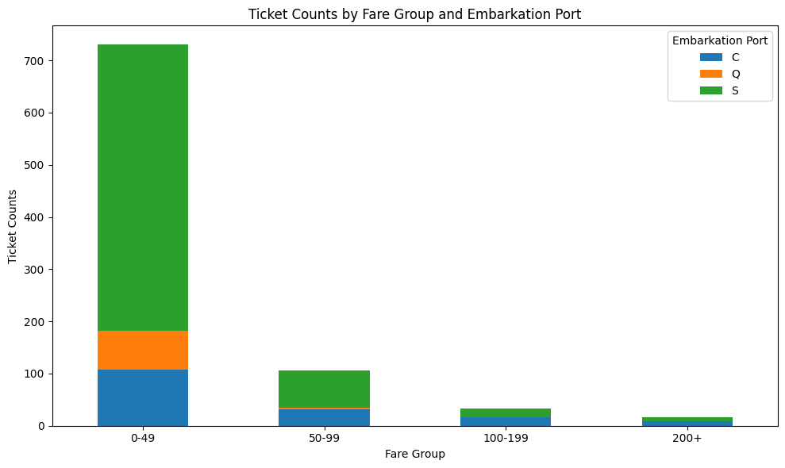

```python
df_fare_embarked_not_null = df.dropna(subset=['Fare', 'Embarked']).copy()
#removes rows with no fare or embarkation data, also copies the original data set

fare_divisions = [0, 50, 100, 200, max(df_fare_embarked_not_null['Fare'])]
#defines fare groups. we chose to seperate fare groups by sets of 50.
fare_ranges = ['0-49', '50-99', '100-199', '200+']
#defines the ranges for the fare prices
df_fare_embarked_not_null.loc[:, 'Fare_Group'] = pd.cut(df_fare_embarked_not_null['Fare'], bins=fare_divisions, labels=fare_ranges, right=False)
fare_group_embarkation_counts = df_fare_embarked_not_null.groupby(['Fare_Group', 'Embarked'], observed=True).size().unstack(fill_value=0)
#counts tickets by fare group and embarkation port

fare_group_embarkation_counts.plot(kind='bar', stacked=True, figsize=(10, 6))
plt.xlabel('Fare Group')
plt.ylabel('Ticket Counts')
plt.title('Ticket Counts by Fare Group and Embarkation Port')
plt.legend(title='Embarkation Port', loc='upper right')
plt.xticks(rotation=0)
plt.tight_layout()
plt.show()
#plotting commands
```

7. Did gender play a role in survival rates?

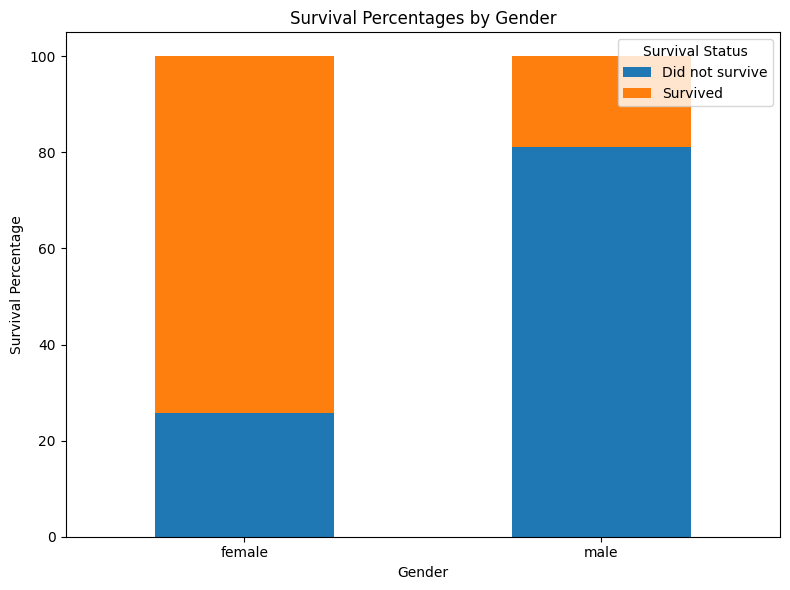

```python
df_gender_survival_not_null = df[['Sex', 'Survived']].dropna().copy()
#removes rows with no sex or survived data, also copies the original data set
#calculates survival percentages by gender
survival_percentages_gender = df_gender_survival_not_null.groupby(['Sex', 'Survived']).size().unstack().fillna(0)
survival_percentages_gender = survival_percentages_gender.div(survival_percentages_gender.sum(axis=1), axis=0) * 100
survival_percentages_gender = survival_percentages_gender.rename({0: 'Did not survive', 1: 'Survived'}, axis=1)

survival_percentages_gender.plot(kind='bar', stacked=True, figsize=(8, 6))
plt.xlabel('Gender')
plt.ylabel('Survival Percentage')
plt.title('Survival Percentages by Gender')
plt.legend(title='Survival Status', loc='upper right')
plt.xticks(rotation=0)
plt.tight_layout()
plt.show()
#plotting commands
```

As seen in the figure, the large majority of survivors were women. This suggests they prioritized women when evacuating the Titanic.